# Boletim Sou da Paz Analisa 2022 - Panorama

Dentre os municípios com maior redução da letalidade policial se destacam Sorocaba, com queda de 66%, Piracicaba, com redução de 64%, São Vicente, com menos 58% mortos, e São José dos Campos, com uma redução de 55% no número de vítimas de letalidade policial.

| ano | COP | n |
| --- | --- | --- |
| 2018 | NÃO | 219 |
| 2018 | SIM | 375 |
| 2019 | NÃO | 219 |
| 2019 | SIM | 445 |
| 2020 | NÃO | 208 |
| 2020 | SIM | 425 |
| 2021 | NÃO | 199 |
| 2021 | SIM | 239 |
| 2022 | NÃO | 168 |
| 2022 | SIM | 106 |

| ano | COP | total | media |
| --- | --- | --- | --- |
| 2018 | NÃO | 219 | 4.211538 |
| 2018 | SIM | 375 | 7.211538 |
| 2019 | NÃO | 219 | 4.211538 |
| 2019 | SIM | 445 | 8.557692 |
| 2020 | NÃO | 208 | 4.000000 |
| 2020 | SIM | 425 | 8.173077 |
| 2021 | NÃO | 199 | 3.826923 |
| 2021 | SIM | 239 | 4.596154 |
| 2022 | NÃO | 168 | 3.230769 |
| 2022 | SIM | 106 | 2.038462 |

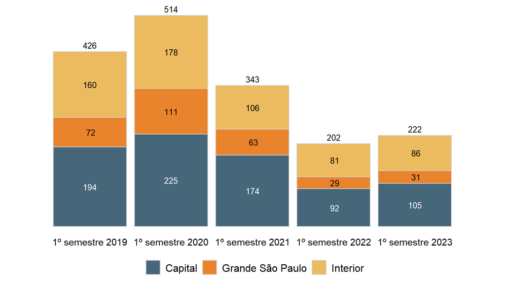

Nos primeiros seis meses do governo Tarcísio as mortes cometidas por policiais voltaram a aumentar após dois anos de intensa queda. O número de vítimas fatais das polícias do Estado de São Paulo foi 10% maior nos primeiros seis meses de 2023 em comparação com o mesmo período do ano anterior: Este aumento da letalidade policial em serviço se concentrou sobretudo na Capital do estado. Houve um aumento de 60% das mortes cometidas por policiais em serviço na cidade de São Paulo, justamente onde há a maior concentração das câmeras operacionais portáteis (COP) do Programa Olha Vivo da PMESP. Ao todo, 72 pessoas foram mortas por policiais em serviço nos primeiros seis meses na capital, contra 45 vítimas fatais de policiais em serviço entre janeiro e junho de 2022.

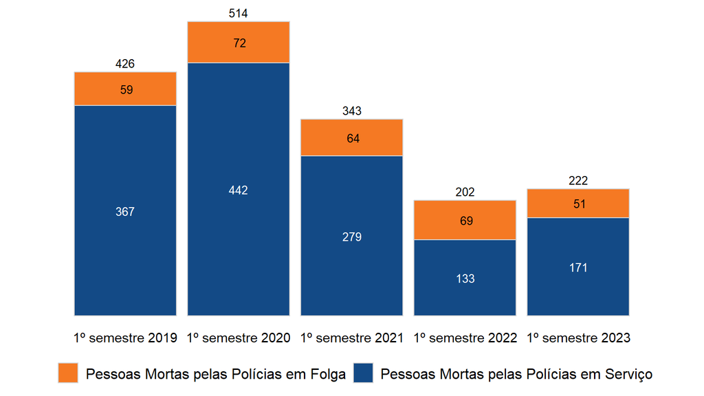

No 1° semestre de 2023 as polícias de São Paulo mataram um total de 222 pessoas: 171 vítimas de policiais em serviço, e 51 pessoas mortas por policiais de folga. Na comparação com o mesmo período do ano anterior, enquanto as mortes cometidas por policiais de folga caíram cerca de 26%, houve um expressivo aumento na letalidade de policiais em serviço:foram 38 vítimas fatais a mais que o mesmo período de 2022, e um crescimento de 28,6% no estado em relação ao primeiro semestre de 2023.

Desta forma, é possível dizer que a letalidade policial no primeiro semestre de 2023 aumentou significativamente, e se concentrou justamente dentre os policiais em serviço e na capital, o que evidencia uma redução da capacidade de redução da letalidade dos mecanismos implementados pela PMESP a partir de meados de 2020.

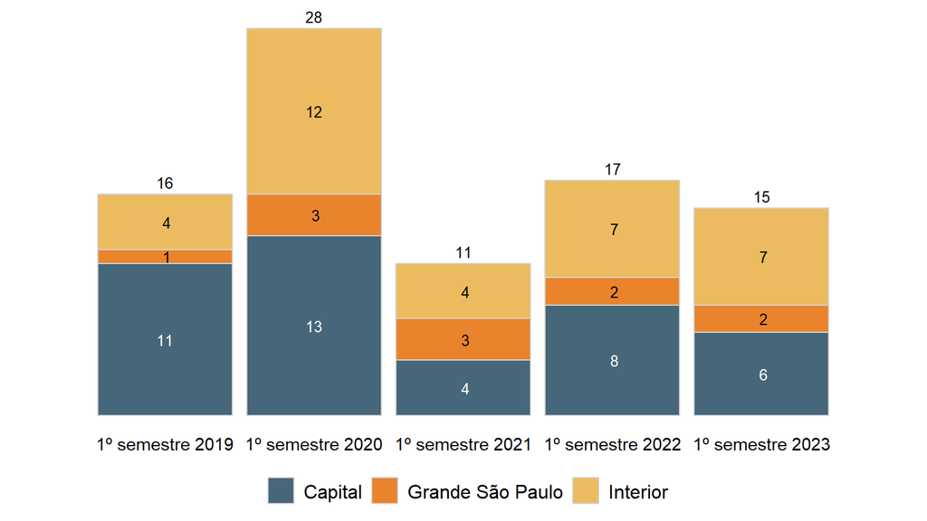

Entre os meses de janeiro e junho de 2023, 15 policiais foram mortos, em serviço e de folga, no estado de São Paulo. Isso significa uma redução de 11,7% em relação à vitimização policial no 1° semestre de 2023.

Esta redução se deu na Capital do estado, onde morreram 6 policiais nos primeiros seis meses deste ano, enquanto nas regiões da Grande São Paulo e do Interior o número de policiais mortos se manteve exatamente o mesmo do que no mesmo período de 2022.

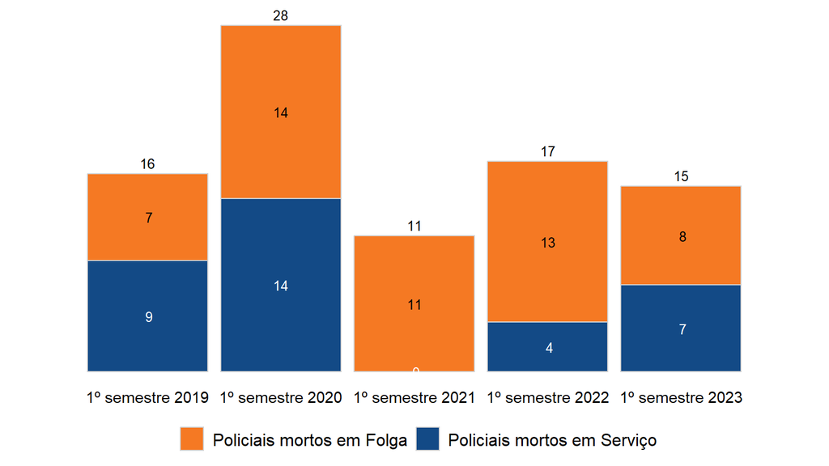